# Survey report: Digital Transformation at NMIs and DIs and use of BIPM digital services (2025)

Authors

Cristhian Paredes

Kazuaki Yamazawa

Published

2026-05-29

DRAFT REPORT FOR THE MEMBERS  
OF THE FORUM-MD SIDF TASK GROUP  
PLEASE DO NOT DISTRIBUTE

## 1 Executive summary

This report summarizes the results of the 2025 BIPM Survey on Digitalization, which gathered responses from 68 National Metrology Institutes (NMIs) and Designated Institutes (DIs) across 61 economies, spanning all six Regional Metrology Organisations (RMOs). The survey covered three broad areas: the digitalization activities of NMIs and DIs, their use of BIPM digital services, and their priorities for the future development of digitalization in metrology.

**Digitalization activities at NMIs and DIs**

Digital calibration certificates (DCCs) are the most advanced digitalization activity across the metrology community: 41.2 % of respondents are actively involved and a further 33.8 % are planning their involvement. Only one institute expressed no interest. The use of Artificial Intelligence (AI) and the adoption of FAIR data principles (Findability, Accessibility, Interoperability and Reusability (Wilkinson et al. 2016)) show similar levels of active engagement. Semantics and ontologies, digital twins, and sensor networks attract lower engagement, with digital twins showing the highest proportion of institutes currently not interested (23.5 %).

**Use of BIPM digital services: web services and APIs**

The KCDB API and the API for Coordinated Universal Time (UTC) are the most widely used BIPM digital services, each used by 10.3 % of respondents. The SIDF website is used by 8.8 % of respondents. The JCTLM API and the Nuclides API are the least known services, with around 60 % of respondents unaware of them. Across all services, the pattern is consistent: limited awareness, few active implementations, and a considerable number of institutes still planning their involvement. The most commonly cited barriers are limited IT capacity, insufficient documentation of the tools, and the absence of practical implementation examples.

**Priorities for future development**

Standardized data formats are considered the most important aspect for further expanding digitalization in metrology, followed by tools for ensuring data validity and machine-readable and machine-actionable documents. Around half of the respondents recognize the potential of AI for data processing and uncertainty evaluation. Development of APIs and ontologies are also considered important. Data format conversion tools and AI models as wrappers for APIs attract the least interest. Across all topics, a recurring expectation emerges: the BIPM should take an active coordination role, provide practical guidance and training, and ensure that its digital services remain accessible to metrologists without requiring advanced IT expertise.

**Tools for data analysis and reporting**

This report was done using Quarto<sup>®</sup> (https://quarto.org/) within the software environment R (https://www.r-project.org/).

For data analysis, the raw data was downloaded from the [JotForm Survey Site](https://form.jotform.com/BIPM/2025-Survey-Digitalization). Data manipulation and visualization was done using tools from the Tidyverse (Wickham et al. 2019). One duplicated answer was removed, and the answers from one of the respondents were translated from Russian to English using a Google Translator API (Iwan 2026).

## 2 Introduction

Three years have passed since the last [survey assessing the status of digital transformation activities in NMIs and DIs](https://www.bipm.org/documents/20126/27085544/RapportBIPM-2023-01.pdf/ff5aac7a-56d7-4ff7-7de1-04d024fedb65) and the landscape has evolved significantly. During this period, the Forum on Metrology and Digitalization ([FORUM-MD](https://www.bipm.org/en/committees/fo/forum-md)) was established by the CIPM, the [Joint Statement of Intent on the digital transformation in the international scientific and quality infrastructure](https://www.bipm.org/en/liaison/digital-transformation) was signed, and the BIPM launched the beta version of the [SI Digital Framework](https://si-digital-framework.org/). This second survey was conducted as a follow-up to collect current information on the needs, priorities, and expectations of NMIs and DIs regarding BIPM digital services.

The survey was open from 9 December 2025 to 9 February 2026, with a small number of deadline extensions granted upon request. A questionnaire was sent to NMI and DI representatives across 258 institutes, asking for a single representative response per institute. The survey was designed to combine option-selection questions with open-ended text fields, allowing both quantitative and qualitative analysis.

The survey covered the following topics:

- Institutes’ services and research activities in digitalization: the status of digital transformation in the services and research projects of NMIs and DIs, including special sections on strategic plans and national policies and requests from stakeholders.
- Use of BIPM digital services: current awareness and use of the digital services offered by the BIPM, split in two sections on BIPM persistent identifiers and the SI Digital Framework APIs and web interfaces.
- Future development of digitalization in metrology: the tools and priorities the community considers most important for further expanding digitalization in metrology.

We received a total of 68 responses from NMIs and DIs of the following 61 economies: Argentina, Australia, Austria, Bahamas, Bangladesh, Barbados, Belarus, Brazil, Bulgaria, Canada, Chile, China, Chinese Taipei, Colombia, Costa Rica, Croatia, Czechia, Ecuador, Egypt, France, Germany, Hong Kong (China), Hungary, India, Indonesia, Ireland, Israel, Italy, Japan, Kazakhstan, Kenya, Malaysia, Mexico, Moldova, Mongolia, Montenegro, Netherlands, New Zealand, Norway, Oman, Peru, Philippines, Poland, Portugal, Republic of Korea, Romania, Russian Federation, Saint Vincent and the Grenadines, Saudi Arabia, Singapore, Slovenia, Spain, Sri Lanka, Sweden, Switzerland, Syrian Arab Republic, Thailand, United Kingdom, United States of America, Uzbekistan, Vietnam.

### 2.1 Profile of respondent Institutes

The 68 responses are from NMIs that are signatories to the Metre Convention, DIs acting under the authority of a signatory NMI, and one institute from a non-signatory economy. Figure 1 presents the distribution by institute type and Figure 2 presents the distribution by Regional Metrology Organisation (RMO). In terms of regional distribution, EURAMET and APMP represent the largest shares of respondents.

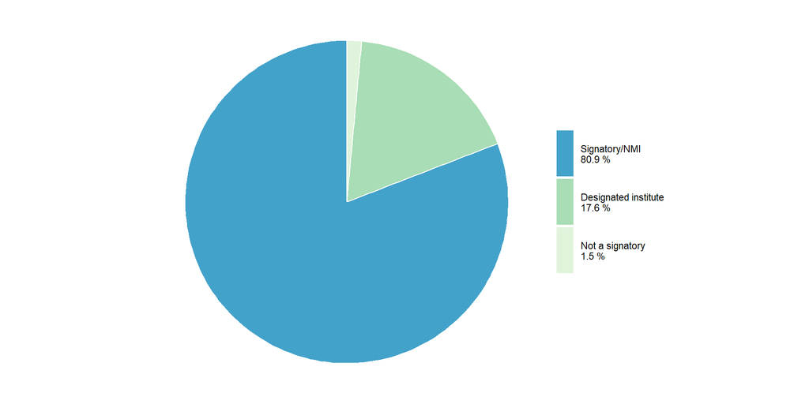

Figure 1: Profile of survey respondents by institute type

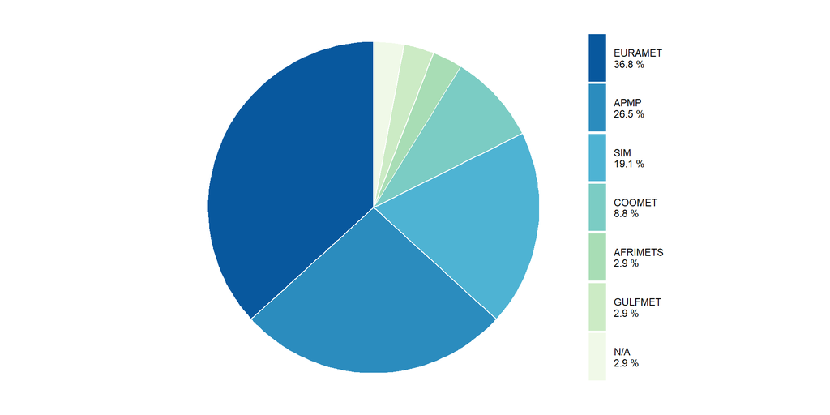

Figure 2: Profile of survey respondents by Regional Metrology Organisation

## 3 Institutes’ services and research activities in digitalization

This section presents the status of digitalization activities across NMIs and DIs, covering both services provided to external stakeholders and internal research projects, whether conducted independently or collaboratively. Six topics were surveyed: digital certificates, use of artificial intelligence, FAIR data practices, semantics and ontologies, digital twins, and sensor networks. For each topic, respondents selected their level of involvement and were invited to provide further details in free text. Figure 3 presents an overview of the responses across all six topics, and the following subsections discuss each in turn.

**See summary data in a table**

Table 1: Work of NMIs and DIs relating digital services

|  | Currently not interested | Thinking about it, but have not decided yet | Planning its involvement | Using it as a tool, but not actively developing | Actively developing it |
| --- | --- | --- | --- | --- | --- |
| Digital certificates | 1.5 % | 23.5 % | 33.8 % | 8.8 % | 32.4 % |
| Use of AI | 4.4 % | 41.2 % | 22.1 % | 8.8 % | 23.5 % |
| FAIR practices | 5.9 % | 36.8 % | 25.0 % | 13.2 % | 19.1 % |
| Semantics / ontologies | 11.8 % | 48.5 % | 16.2 % | 5.9 % | 17.6 % |
| Digital twins | 23.5 % | 35.3 % | 14.7 % | 4.4 % | 22.1 % |
| Sensor networks | 16.2 % | 42.6 % | 13.2 % | 7.4 % | 20.6 % |

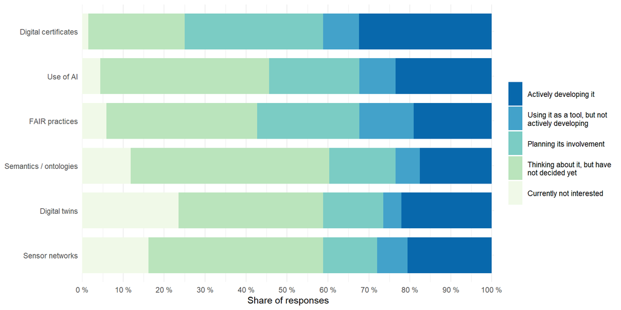

Figure 3: NMI Services

### 3.1 Digital Certificates

Figure 4 presents the level of engagement of respondents with digital certificates. With 32.4 % actively developing solutions and 8.8 % using them as a tool, digital certificates show by far the highest level of active involvement among the six topics. A further 33.8 % are planning their involvement, and only one institute (1.5 %) is currently not interested. This expected trend reponds to the factthat digital certificates have been a topic of active discussion in the metrology community for several years and represent the most direct and tangible output of NMIs and DIs.

The majority of institutes focus on calibration certificates and a smaller share include digital certificates for reference materials. For the latter, one institute highlighted the assignment of DOIs to improve the machine-actionability of their metrological information.

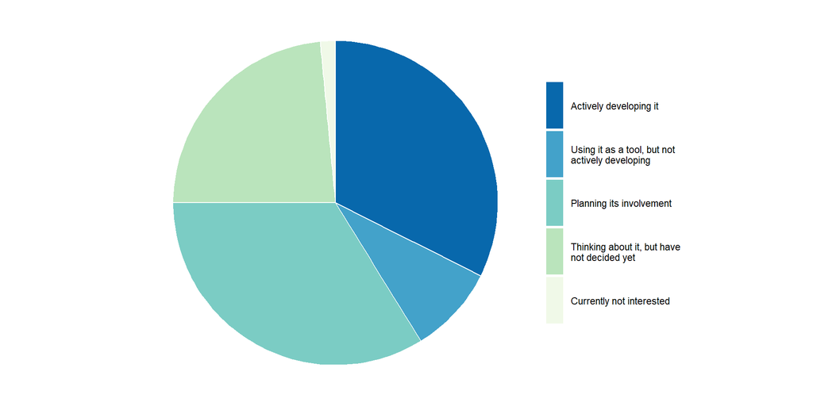

Figure 4: NMIs’ and DIs’ engagement with digital certificates

**See more details**

The free-text responses reveal a diverse landscape of approaches and maturity levels. File formats vary widely: many institutes adopt XML schemas developed by PTB, others develop their own XML schemas, and others use PDF (including PDF/A-3) as a container embedding machine-readable data. Some institutes include QR codes or barcodes alongside the certificate. The data attached is not always limited to raw measurement values, but some institutes also include correlation information between multivariable measurands to better support measurement uncertainty propagation. A minority of institutes explicitly address data integrity measures such as electronic signatures or hash digests. It is interesting that there are various approaches to achieve machine readability, either having a machine-readable file providing human readability with additional operation or having a human friendly document as a wrapping container with machine readable digital data embedded and extractable.

Only a small number of institutes have described their practice on data integrity such as application of electronic signatures or providing hash digest information. However, such considerations seem to be also an underlying factor in selecting the file format, balancing also with other constraints to effectively serve their stakeholders.

Institutes in the planning stage face additional challenges beyond the technical, including administrative or legal barriers and the development of customer-facing interfaces for certificate delivery.

Due to differences in methodology and scope between this survey and the [previous one conducted in 2022/2023](https://www.bipm.org/en/doi/10.59161/rapport202301), the results are not directly comparable. Nevertheless, the depth and specificity of the responses suggest that institutes have considerably advanced their thinking on how measurement data is delivered to customers through digital certificates.

Despite many responses discussed the data format of their DCCs, there were no responses explaining in detail how the DCCs are provided to the customers or the method how the customer can confirm that the most recent information is used in concern of recalls or withdrawal of DCCs after their issue where at the point of the issue that the digital file conveyed “genuine data to be used” but when at a later point that it was found to be faulty.

### 3.2 Use of Artificial Intelligence

With the remarkable spread of the services available utilizing Artificial Intelligence, the use of Artificial Intelligence to activities of NMIs and DIs seems to have grown interest.

Figure 5 presents the level of engagement of respondents with artificial intelligence. Nearly a quarter (23.5 %) are actively developing AI-based solutions, and 8.8 % are using AI as a tool without active development. A further 22.1 % are planning their involvement, 41.2 % have not yet decided, and only 4.4 % are currently not interested.

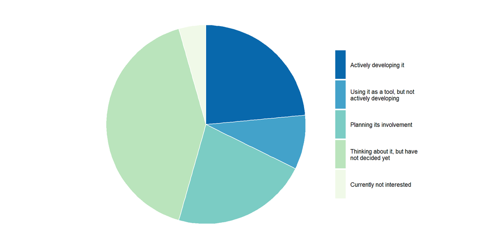

Figure 5: NMIs’ and DIs’ engagement with artificial intelligence

**See more details**

Because the survey asked specifically about the *use* of AI, responses naturally focus on applications rather than on the broader question of AI trustworthiness or metrology for AI. Institutes actively developing AI solutions tend to work on specific measurement applications involving large volumes of data with common themes including uncertainty analysis, material characterization, data mining, and automated verification for legal metrology. Institutes using AI as a tool without active development tend to focus on customizing existing large language models through prompting, or on using AI to handle customer inquiries.

The responses collected here primarily describe the domains in which institutes are applying AI. Questions of output quality, transparency, and traceability of AI-derived results appear infrequently. Those topics are likely to grow in importance as AI adoption in metrology deepens and the parallel question of “metrology for AI” becomes more pressing.

### 3.3 FAIR practices

Figure 6 presents the level of engagement of respondents with FAIR principles (Wilkinson et al. 2016). 19.1 % are actively developing services based on FAIR principles, 13.2 % are using them, and 25 % are planning to do so. 36.8 % have not yet decided, and 5.9 % are currently not interested.

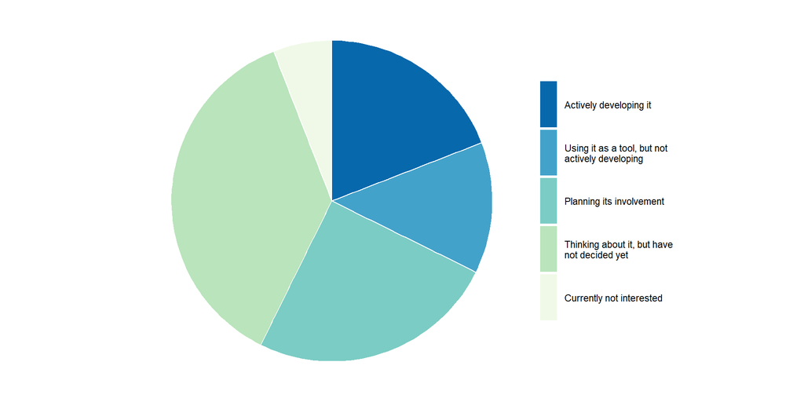

Figure 6: NMIs’ and DIs’ engagement with services related to FAIR principles

**See more details**

FAIR data principles are widely associated with the concept of data traceability in the metrological context. Institutes actively developing activities tu implement FAIR principles typically focus on building databases or data management systems, covering the data they produce and external references. Institutes using FAIR as a tool tend to express it through the development of internal guidelines. The adoption of digital calibration certificates appears to be a strong driver of FAIR implementation across the community.

### 3.4 Semantics and ontologies

Figure 7 presents the level of engagement of respondents with semantics and ontologies. 17.6 % are actively developing in this area, but only 5.9 % report using existing resources without active development. The remaining respondents are planning (16.2 %), undecided (48.5 %), or not interested (11.8 %).

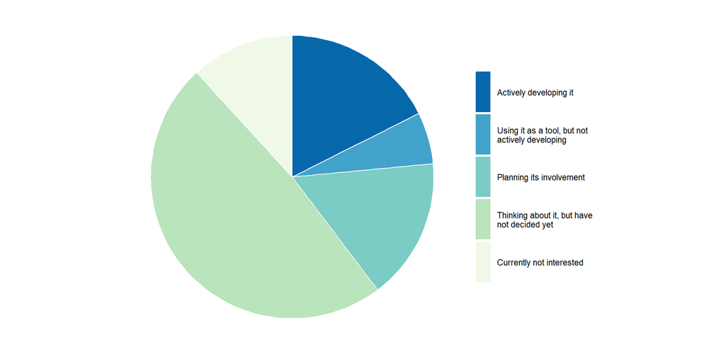

Figure 7: NMIs’ and DIs’ engagement with Semantics and Ontologies

**See more details**

The active work in this area is diverse. Some institutes work at a high conceptual level developing vocabularies that could serve as extensions of the International Vocabulary of Metrology (VIM) (Joint Committee for Guides in Metrology 2012), while others focus specifically on the representation of SI units. More application-oriented projects include the M-layer, measurement taxonomy frameworks, and the digital representation of OIML concepts. Although several responses connect semantics and ontologies to DCC development, the importance of this topic for digital certificates does not appear to be widely recognized.

### 3.5 Digital twins

Figure 8 presents the level of engagement of respondents with digital twins. 22.1 % are actively developing in this area and 4.4 % are using digital twins as a tool. The remaining respondents are planning (14.7 %), undecided (35.3 %), or not interested (23.5 %). This topic presented the highest proportion of disinterest among the six topics.

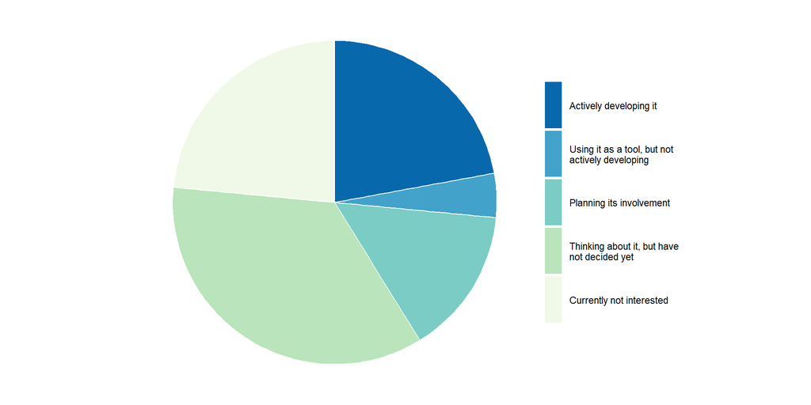

Figure 8: NMIs’ and DIs’ engagement with Digital Twins

**See more details**

Active development include traditional digital twin applications such as 3D models for coordinate measuring systems, and include newer applications like sensor network modelling, photoplethysmography, and battery simulation. The relatively sparse responses in this subsection may reflect that the topic is still at an early stage for many institutes. Nonetheless, recurring references to uncertainty evaluation in the responses suggest an underlying interest that is yet to fully materialize.

### 3.6 Sensor networks

Figure 9 presents the level of engagement of respondents with sensor networks. 20.6 % are actively developing in this area and 7.4 % are using sensor networks as a tool. The remaining respondents are planning (13.2 %), undecided (42.6 %), or not interested (16.2 %).

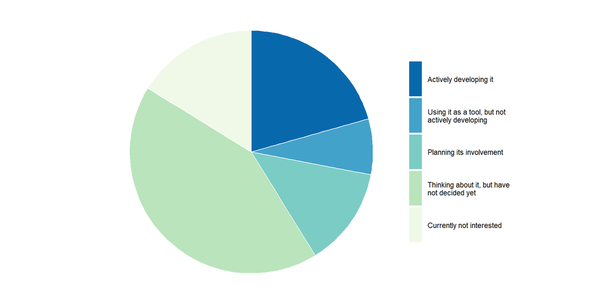

Figure 9: NMIs’ and DIs’ engagement with sensor networks

**See more details**

Environmental monitoring and power and water distribution applications are the most common areas of development for this topic. Projects frequently involve machine learning and neural networks for fault detection and uncertainty evaluation, with some institutes researching the challenge of in-situ self-calibration of sensors. Temperature, humidity, and pressure are the most common measurands, reflecting the wide availability of low-cost commercial sensors and the relevance of these quantities to environmental monitoring, workplace safety, and energy management.

### 3.7 Other areas of metrology

Beyond the six topics above, many institutes reported digitalization activities in adjacent areas. The most common themes are the modernization of customer-facing interfaces like web portals for calibration scheduling, digital certificate delivery, and administrative transactions, and internal improvements such as environmental monitoring of laboratory facilities, automated report generation, centralized document control, and quality management systems.

### 3.8 Strategic plans and national policies

Several institutes provided information on broader strategic digitalization plans reflecting priorities set at the governmental level. Some institutes indicated they do not disclose strategic plans externally, and a small number reported no formal digitalization strategy specific to metrology. Among those who shared their plans, the most commonly cited priorities are:

- Development of calibration and test automation technology
- Development of laboratory activity outputs such as establishing DCCs and digital certificates for reference materials.
- Use of AI for automation
- Digitalization of customer’s user interface with the institutes
- Creation of a digital infrastructure through development of secure data exchange to support smart manufacturing and supply chains
- Spread digitalization by NMI/DIs supporting the domestic laboratories
- Digital twins
- Sensor networks
- Software assessment

### 3.9 Requests from stakeholders

The most common requests from stakeholders concern digital user-facing interfaces: portals giving clients direct access to metrological services, including administrative functions such as scheduling and transactions. Digital Calibration Certificates are explicitly requested by the stakeholders of several institutes.

For many institutes, their stakeholders remain passive on digitalization, waiting for further development on the institute side, or expecting broader standardization to establish a common workflow independent from a specific NMI or DI as their service provider instead of committing to a specific workflow.

## 4 Use of BIPM digital Services

NMIs and DIs were asked about their awareness and use of the digital services offered by the BIPM. For each service, respondents were asked to position their institute on a scale ranging from not being aware of the service to actively contributing to its development. This section presents the results grouped into two broad categories: the BIPM persistent identifiers (PIDs), which allow institutions to reference SI concepts and KCDB data in a stable, machine-actionable way, and the suite of APIs and web interfaces that make up the [SI Digital Framework](https://si-digital-framework.org/) ecosystem. The findings help identify where awareness-raising and capacity-building efforts may be most needed.

### 4.1 BIPM Persistent Identifiers

The use of PIDs is a cornerstone of interoperable digital infrastructure. When a digital certificate, a laboratory system, or a data pipeline references a measurement unit, a defining constant or a CMC via a PID, that reference is unambiguous and resolvable by any system without relying on free text or local conventions. By anchoring those concepts to BIPM-maintained PIDs, NMIs and DIs can improve the interoperability of their data and services. The current PIDs offered by the BIPM are stable, resolvable URIs that allow humans and machines to unambiguously reference measurement information in a way that is both machine-actionable and linked to authoritative definitions.

Respondents were asked to indicate which of the BIPM PIDs their institute currently uses. The results are summarised in Figure 10. The CMC PID is the most widely used, with 86.8 % of respondents reporting its use. Adoption is considerably lower for the SI Reference Point PIDs: 47.1 % use the PIDs for units and prefixes, and around a third use those for defining constants and quantities. Further details provided by respondents are highlighted in the subsections below.

**See summary data in a table**

Table 2: Use of BIPM PIDs by the NMIs

|  | Share |
| --- | --- |
| PIDs of CMCs | 86.8 % |
| PIDs of units and prefixes from the SIRP | 47.1 % |
| PIDs of defining constants from the SIRP | 33.8 % |
| PIDs for types of quantity in the SIDF | 32.4 % |

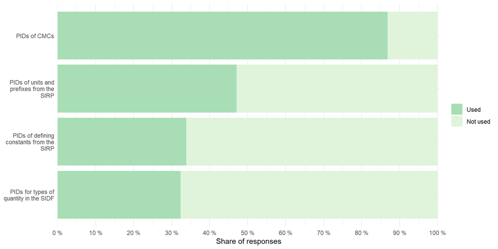

Figure 10: Proportion of respondents that reported using each of the four PID types offered by the BIPM.

#### 4.1.1 PIDs for Calibration and Measurement Capacities in the KCDB

Each CMC is assigned a unique identifier constructed programmatically by the KCBD (see [Quick start guide](https://www.bipm.org/documents/20126/43909385/QUICK_START_CMC-identifiers.pdf/2de963af-5737-2fd8-4960-d6bbb6c9e67e)). The BIPM provides a dedicated URL resolver at https://si-digital-framework.org/kcdb-cmc/, that enables persistent, machine-readable links to individual CMC entries. For example, the CMC **AFRIMETS-EM-KE-00000MUX-1** has the PID https://si-digital-framework.org/kcdb-cmc/AFRIMETS-EM-KE-00000MUX-1, that humans can visit in a webpage, or that machines can request in JSON or XML format.

The current applications of the PIDs for CMCs by NMIs and DIs include:

- Automated validation of traceability chains
- Inclusion as machine readable references in DCCs
- Inclusion as web-resolvable references in traditional calibration certificates
- Inclusion as references in certificates of reference materials
- References on institutional web platforms and client portals
- References in internal databases
- Linking traceability statements and cross-referencing measurement services
- Use in measurement reports and the documentation of the Quality System
- Inclusion in annual reports to the corresponding Regional Metrology Organization
- Referencing in the CMCs peer review report

Many NMIs and DIs have expressed their willingness to use such PIDs more broadly in the future. However, **there is no consensus on whether the CMC PID should be included as a bare identifier or as a resolvable URL**.

#### 4.1.2 PID for units and prefixes from the SI Reference Point

Each unit and prefix in the SI Brochure and their allowed combinations are assigned a unique, stable identifier in the SI Reference point (). For example, the SI unit metre per millisecond has the PID https://si-digital-framework.org/SI/units/metre.millisecond-1, which humans can visit as a webpage or machines can request in JSON-LD or Turtle format.

The main reasons to use the PIDs are to avoid human error and unit mismatch, ensuring to obtain the up-to-date data and definitions. The main use of units and prefixes PIDs are:

- Inclusion in DCC, digital calibration reports, and digital measurement data in general
- Linking other digital representations for units of measurement to the authoritative digital representation
- References in machine-readable reports and metrological documents
- Embedding unit PIDs in data analysis workflows to ensure consistent unit handling
- References on the quality management platform

Some institutes highlighted that the is still in beta stage, upholding them from using it on a larger scale.

#### 4.1.3 PIDs for Defining Constants in the SI Reference Point

Each defining constant of the SI is assigned a unique, stable identifier in the SIRP. For example, the Planck constant has the PID https://si-digital-framework.org/constants/PlanckConstant, which resolves to a human-readable webpage or a machine-readable representation in JSON-LD or Turtle format. Reported applications include:

- Integration into *mise en pratique* for the experiments that realize the SI units
- Linking other constants in ontologies to the authoritative digital representation
- Inclusion in data analysis workflows, results reporting and inclusion in DCCs
- References in reports and presentations

Most respondents describe their engagement as planned or not yet started, with interest expressed in combining these PIDs with those from other systems such as [CODATA’s API](https://api.codata.org/drum/constants/).

#### 4.1.4 PIDs for types of quantity in the SI Digital Framework

Each quantity mentioned in the CMCs recorded in the KCDB are also assigned PIDs in the SIDF. For example, the quantity *electric field strength* has the PID https://si-digital-framework.org/quantities/ELFS, resolving to a human-readable webpage or a machine-readable representation in JSON-LD or Turtle format.

The main use of the quantity PIDs is to make the CMCs recorded in the KCDB more consistent with the SI Digital Framework. To achieve this goal, the quantities PID are associated with the KCDB Service categories and with default units of measurement from the SI. After validation with the consultative committees, new CMC entries will be able to automatically evaluate that the units of measurement reported in the CMC claim is consistent with the service category being used.

Some institutes were interested in using the PIDs for quantities in the machine-readable reports, calibration certificates and quality management documents.

### 4.2 SI Digital Framework, SI Reference Point, APIs & Databases

Beyond persistent identifiers, the BIPM offers a suite of web interfaces and application programming interfaces (APIs) that provide programmatic access to key metrological databases and authoritative metrological information and reference data. These include:

- The API for the Key Comparison Database (KCDB)
- The API for the database of the Joint Committee for Traceability in Laboratory Medicine (JCTLM)
- The Websites for the SI Digital Framework (SIDF) and the SI Reference Point (SIRP)
- The SIRP API for units and constants and the SIDF API for quantities
- The SIDF API for individual CMCs
- The SIDF API for service categories in the KCDB
- The SIDF API for nuclides
- The API for recommended values of standard frequencies
- The API for Coordinated Universal Time (UTC) and time scales
- Other services

Respondents were asked to indicate their level of engagement with each of these services, from unawareness through to active implementation or contribution to development. The results reveal a wide variation in awareness and adoption across services, with the KCDB API being the most familiar. Some services are designed for specialized measurement areas, like the APIs for nuclides and the JCTLM database, consequently being the least known among respondents. Figure 11 presents the share of respondents from the institutes to these questions.

Major highlights regarding the responses about services by the BIPM are:

- One of the most common intended uses of the digital tools by the BIPM is to incorporate them in data treatment workflows and quality system documentation
- The production of DCCs is one of the main uses for the BIPM digital services.
- The KCDB and the SIDF tools should be more consistent among themselves.
- It would be beneficial to have access to all digital services by the BIPM on a single entry point.
- The representation of exact values of defining constants is beyond the floating-point precision that is currently implemented in the API.
- High demand for services’ promotion and knowledge transfer with practical examples

**See summary data in a table**

Table 3: Use of BIPM digital services by the NMIs

|  | Is not aware of it | Knows the service, but not its potential benefits | Knows the service and its benefits, but is not sure how to use it | Is planning (or developing) internal services that use the BIPM digital service | Has implemented services that depend/rely on the BIPM digital service | Is contributing to the development of the digital service at the BIPM |
| --- | --- | --- | --- | --- | --- | --- |
| KCDB API | 27.9 % | 20.6 % | 19.1 % | 17.6 % | 10.3 % | 4.4 % |
| JCTLM API | 55.9 % | 14.7 % | 25.0 % | 4.4 % | 0.0 % | 0.0 % |
| SIDF website | 26.5 % | 19.1 % | 20.6 % | 20.6 % | 8.8 % | 4.4 % |
| SIRP website | 29.4 % | 22.1 % | 17.6 % | 20.6 % | 5.9 % | 4.4 % |
| SIRP API for Units of measurement | 33.8 % | 25.0 % | 13.2 % | 22.1 % | 1.5 % | 4.4 % |
| SIRP API for CMCs | 35.3 % | 16.2 % | 20.6 % | 19.1 % | 5.9 % | 2.9 % |
| SIRP API for Service Categories | 38.2 % | 20.6 % | 19.1 % | 16.2 % | 2.9 % | 2.9 % |
| SIRP API for nuclides | 66.2 % | 16.2 % | 13.2 % | 2.9 % | 1.5 % | 0.0 % |
| API for Standard Frequencies | 39.7 % | 17.6 % | 27.9 % | 8.8 % | 4.4 % | 1.5 % |
| API for UTC and Time Scales | 42.6 % | 11.8 % | 25.0 % | 8.8 % | 10.3 % | 1.5 % |

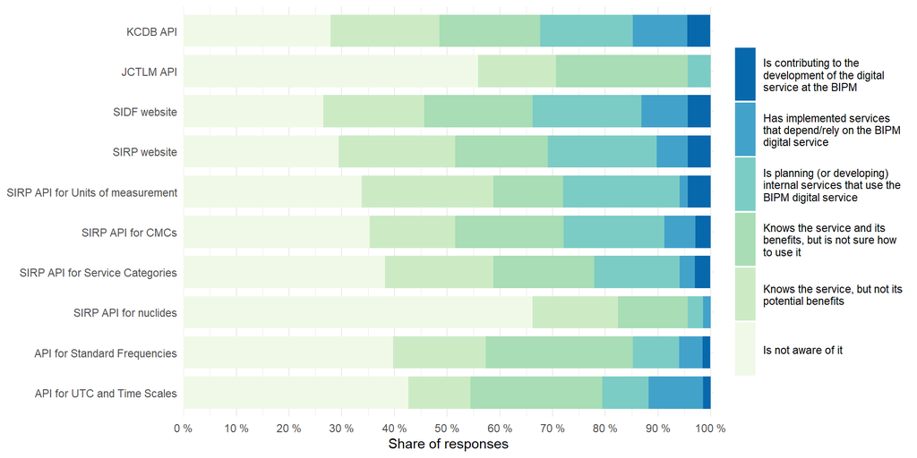

Figure 11: Use of BIPM digital services by the NMIs

#### 4.2.1 API of the KCDB

The [KCDB API](https://www.bipm.org/api/kcdb/swagger-ui/index.html?configUrl=/api/kcdb/v3/api-docs/swagger-config#/) provides machine-readable access to all records of calibration and measurement capabilities. Figure 12 presents the level of engagement reported by respondents. Despite being the most widely known of the BIPM APIs, a significant share of respondents indicated that their institutes are not aware of it (27.9 %) or know of it but are unfamiliar with its potential benefits (20.6 %). A small portion has implemented, is developing, or is planning services that rely on the KCDB API (27.9 %), and 4.4 % are actively contributing to its development at the BIPM.

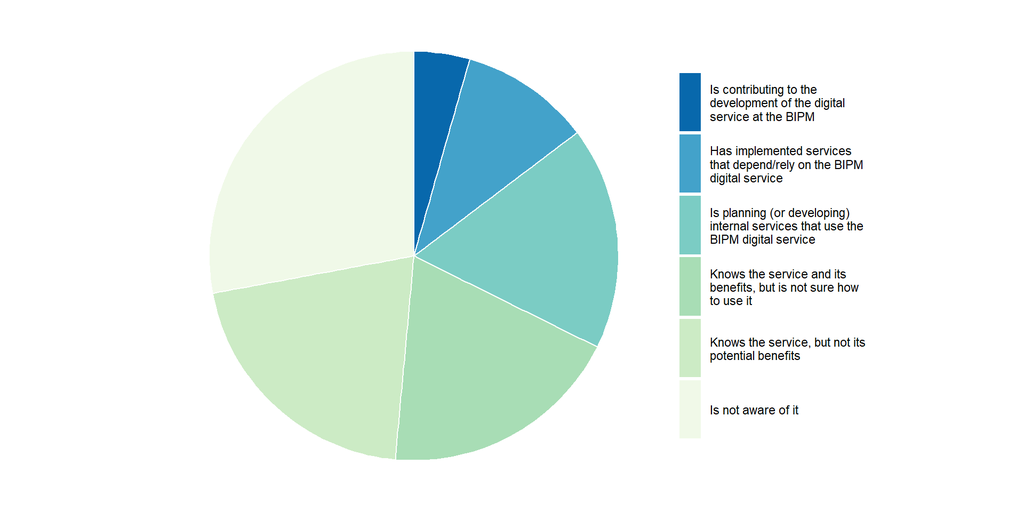

Figure 12: NMIs’ and DIs’ usage withthe BIPM Digital Service: KCDP API

Current uses of the API are:

- Wrapping and redistributing CMC data for regional audiences
- Statistical analysis of CMC data and Visualisation of NMI service coverage
- Accessing CMC uncertainty values to support service uncertainty estimation
- DCC-related services development

Future uses and current desires include:

- Displaying institute CMCs on regional and institutional websites
- Automated retrieval and internal synchronisation of CMC data
- Filtering and comparison of CMC data across institutes
- Embedded tools for comparison planning and monitoring within the KCDB

There is a growing demand that better links be established between the KCDB API and SIDF units and quantity definitions. This is part of the work programme for digitalization at the BIPM.

#### 4.2.2 API of the JCTLM database

Current uses of the JCTLM API: No institute reported an active implementation of the JCTLM API. Several respondents access JCTLM information manually through the web portal, and one uses it as a reference for traceability and reference materials. To improve the promotion being done to the tool, some respondents suggested including a link from the SI Digital Framework webpage.

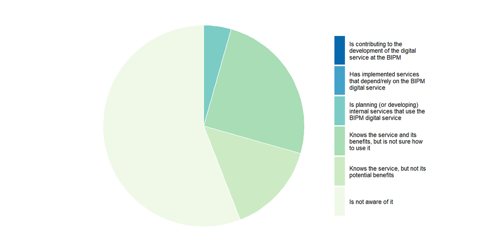

Figure 13: NMIs’ and DIs’ usage of the BIPM Digital Service: JCTLM API

#### 4.2.3 SI Digital framework website

The [SIDF website](https://si-digital-framework.org/) serves as the human-facing interface providing access to definitions of units, quantities, prefixes, and defining constants, along with their persistent identifiers. Figure 14 presents the level of engagement reported by the respondents. A significant share of the respondents indicated that their institutes are not aware of this service (26.5 %) or that, despite knowing the service, the potential benefits are unknown (19.1 %). A small portion has developed, is developing, or is planning to develop services that rely on the webpage (29.4 %). 4.4 % of respondents are actively contributing to the development of the webpage at the BIPM.

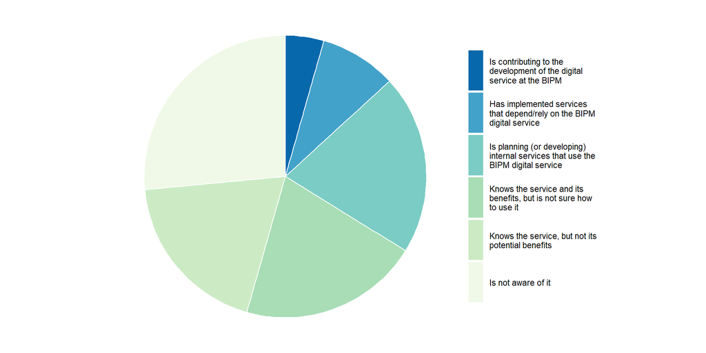

Figure 14: NMIs’ and DIs’ usage of the webpage for the SI Digital Framework

Although the website is valuable as a reference for internal discussions and as a search tool for SI concepts, several institutes highlighted that the service would be more effective after the BIPM performs knowledge transfer to help users get the most from the service, providing example scripts in common languages. Some institutes declared that it would be beneficial to have a single unified webpage giving access to all BIPM digital services.

#### 4.2.4 SI Reference Point website

The SIRP is part of the core layer services of the SI Digital Framework. The [SIRP webpage](https://si-digital-framework.org/SI), as was the case with the webpage of the SI Digital Framework is not strictly speaking a digital service. This website serves as a point of entry for humans to start interacting with the knowledge base of the SI Reference Point. Figure 15 presents the level of usage of the website by the respondents. Many institutes acknowledged the importance of the website, however, a big portion of the respondents indicated that their institutes are not aware of this service (29.4 %) or that, despite of knowing the service, the potential benefits are unknown (22.1 %). A small portion has developed, is developing, or is planning to develop services that rely on the webpage (26.5 %). 4.4 % of respondents are actively contributing to the development of the webpage at the BIPM.

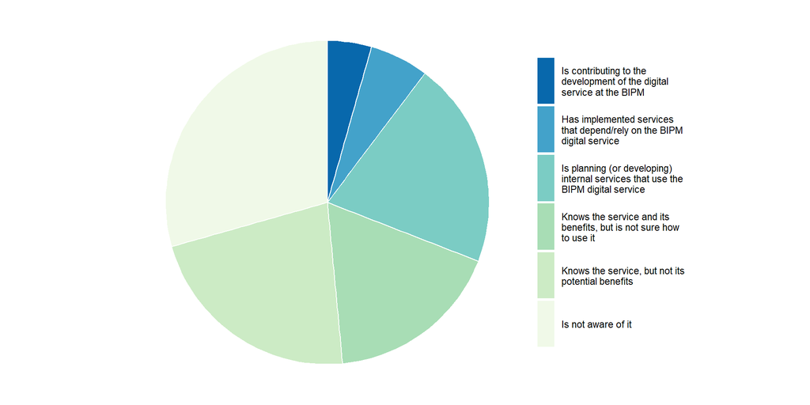

Figure 15: NMIs’ and DIs’ usage of the webpage for the SI Reference Point

Among the respondents already using it, the main application is incorporating the digital representation of quantities and units from the SIRP into DCCs. One institute reported using it to build a knowledge graph from the Turtle files for exploration purposes. As with the SIDF website, several respondents called for more promotion, practical examples, and training to lower the barrier to adoption.

#### 4.2.5 SI Reference Point API for units and constants and the SI Digital Framework API for quantities

The BIPM offers the [API controllers for querying units of measurement, prefixes, defining constants and quantities used in the KCDB](https://si-digital-framework.org/api-docs/swagger-ui/?urls.primaryName=SI%20REFERENCE%20POINT#/SI%20units). The API returns machine-actionable definitions for the units of measurement defined in the SI Brochure and the composed units that can be constructed coherently with the SI Brochure rules. Figure 16 presents the level of usage of the API for units of measurement, constants and quantities.

The majority of the respondents indicated that their institutes are not aware of this service (33.8 %) or that, despite of knowing the service, the potential benefits are unknown (25 %). A small portion has developed, is developing, or is planning to develop services that rely on the service (23.6 %). 4.4 % of respondents are actively contributing to the development of the service at the BIPM.

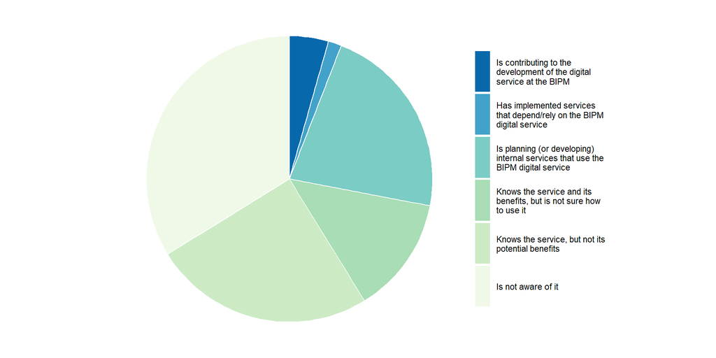

Figure 16: NMIs’ and DIs’ usage of the API for units of measurement, constants and quantities

Current uses of these APIs include:

- Automated retrieval of unit, constant and quantity definitions for DCC issuance
- Integration into non-SI unit translation and quantity representation services
- Supporting the development of a national digital reference system for quantities and units

Current desires and future implementations:

- Integration of pulled data as part of DCC workflows
- Integration into institutional software and platforms for extracting SI information
- Sandbox environment and practical integration examples for quality systems
- Clarification of data reuse policies for national-scale deployment
- Representation of exact values of defining constants beyond floating point precision

#### 4.2.6 SI Digital Framework API for individual CMCs

The SI Reference Point offers the API for querying details of individual CMCs that have been recorded in the KCDB. This includes current and past CMCs that were superseded, deleted or greyed-out. The Figure 17 presents the level of usage of the API for CMCs in the SIDF. A big portion of the respondents indicated that their institutes are not aware of this service (35.3 %) or that, despite of knowing the service, the potential benefits are unknown (16.2 %). A small portion has developed, is developing, or is planning to develop services that rely on the service (25 %). 2.9 % of respondents are actively contributing to the development of the service at the BIPM.

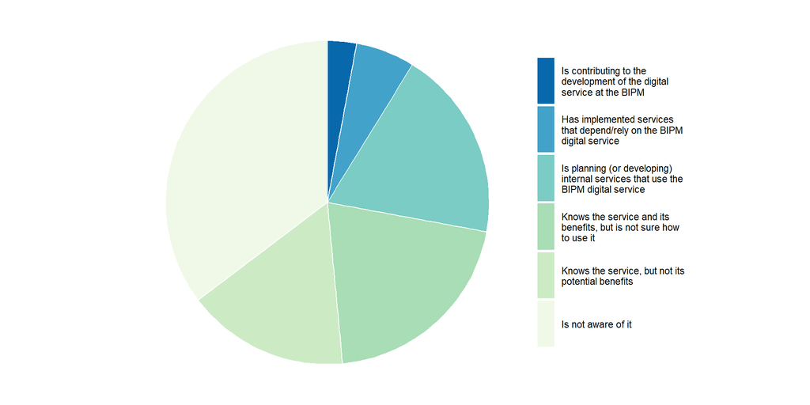

Figure 17: NMIs’ and DIs’ usage of the SI Reference Point API for Calibration and Measurement Capabilities

Current uses:

- Automated querying of CMC uncertainty values and equations for comparison against in-house calibration software
- NMI service coverage visualisation tool, publicly available on GitHub
- Wrapping KCDB CMC data for domestic users via the National Metrology Data Center
- Integration into QM documentation and service portal
- Automated CMC data retrieval linked to internal databases

Current desires and future implementations:

- Integration into DCC issuance systems
- Automated review of calibration report data against CMCs, including for RMO CMC review processes
- Practical guides for implementation in calibration certificate and test report workflows
- Improved navigation between CC classifications, quantities and country-specific CMCs

#### 4.2.7 SI Digital Framework API for Service Categories

The API for querying Service Categories recorded in the KCDB returns the KCDB service categories associated with each quantity in the SI Reference Point, along with their persistent identifiers and links to the related quantities. Note that Chemistry and Biology service categories are not yet covered.

Figure 18 presents the level of usage of the API for Service Categories. A big portion of the respondents indicated that their institutes are not aware of this service (38.2 %) or that, despite of knowing the service, the potential benefits are unknown (20.6 %). A small portion has developed, is developing, or is planning to develop services that rely on the service (19.1 %). 2.9 % of respondents are actively contributing to the development of the service at the BIPM.

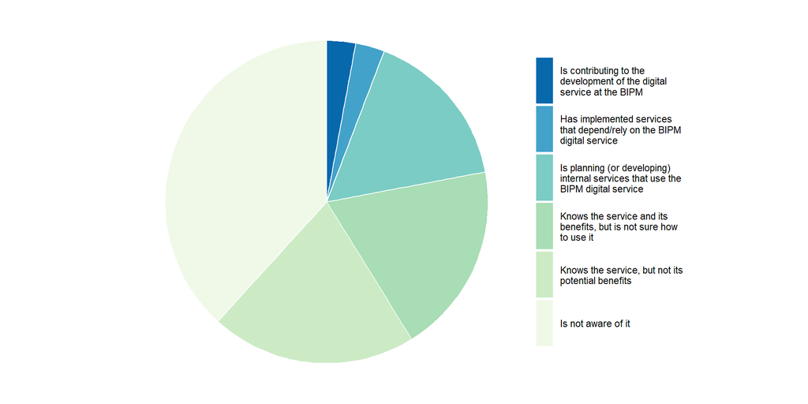

Figure 18: NMIs’ and DIs’ usage of the SI Reference Point API for Service Categories

Current uses:

- NMI service coverage visualisation tool, in combination with the CMC API
- Supporting consistency checks between the KCDB and SIDF

Current desires and future implementations:

- Linking to calibration certificates and DCC workflows
- Classifying and unifying service type descriptions
- Better promotion and documentation of the purpose and scope of this API

#### 4.2.8 SI Digital Framework API for Nuclides

The API for Nuclides provides machine-readable access to a knowledge base with the nuclides for which CMCs in ionizing radiation have been submitted at the KCDB. The Figure 19 presents the level of usage of this API. Most of the respondents indicated that their institutes are not aware of this service (66.2 %). A very small portion has developed, is developing, or is planning to develop services that rely on the service (4.4 %).

This API is mainly intended to be consumed by the KCBD in the process of harmonizing it with the other parts of the SI Digital Framework.

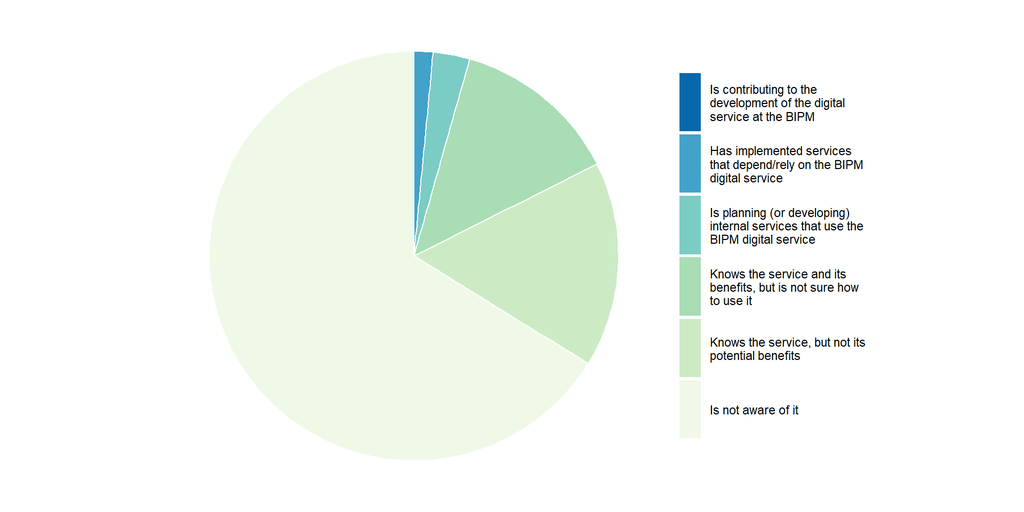

Figure 19: NMIs’ and DIs’ usage of the SI Digital Framework API for Nuclides

#### 4.2.9 API for recommended values of standard frequencies

The Time Department of the BIPM developed the [API for querying the standard frequencies](https://webtai.bipm.org/webdb/api/ccl-cctf/) that are jointly published by the CIPM’s Consultative Committee for Length (CCL) and Consultative Committee for Time and Frequency (CCTF). The standard frequencies are used for primary realizations of the metre (Lewis et al. 2022) and secondary realizations of the second. Figure 20 presents the level of usage of the API for standard frequencies. A large portion of the respondents indicated that their institutes are not aware of this service (39.7 %). A small portion has developed, is developing, or is planning to develop services that rely on the service (13.2 %). 1.5 % of respondents are actively contributing to the development of the service at the BIPM.

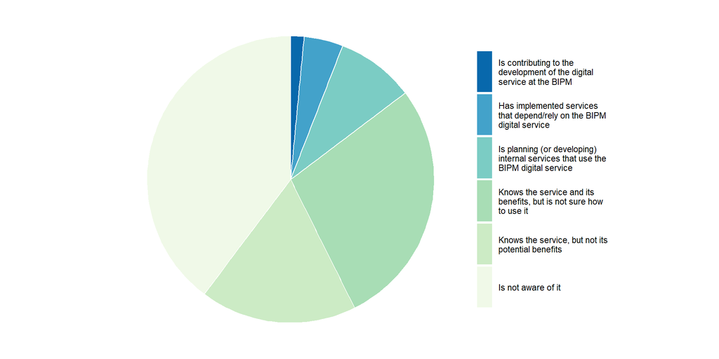

Figure 20: NMIs’ and DIs’ usage of the SI Digital Framework API for Standard Frequencies

Among those with active implementations, the most concrete use is the retrieval of standard frequency data in real-time measurement software and in metre realisation laser systems. Several institutes are in early planning stages, primarily in the context of DCCs. A notable suggestion concerns the inclusion of new frequency recommendations and anticipates the evolution of the service in the case of the future redefinition of the second in the SI.

#### 4.2.10 API for UTC Data and Time Scales

The Time Department of the BIPM developed the [Time Department API Web Service](https://webtai.bipm.org/webdb/api/v1.0/) that provides machine-readable data regarding various time scales, including UTC and rapid UTC. Figure 21 presents the level of usage of the API for this service. (42.6 %) of the respondents indicated that their institutes are not aware of this service, mainly because time and frequency activities fall under the scope of a designated institute. A small portion has developed, is developing, or is planning to develop services that rely on the service (19.1 %). 1.5 % of respondents are actively contributing to the development of the service at the BIPM.

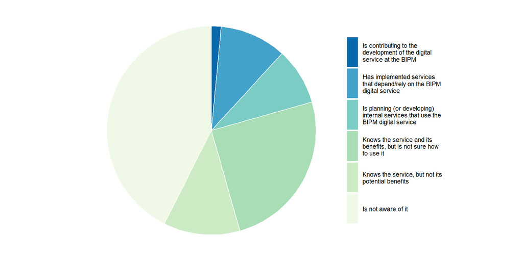

Figure 21: Level of usage of the SI Digital Framework API for UTC and Time scales

Among the institutes with active implementations, the most common use is the automated retrieval of UTC and rapid UTC data to feed clock steering algorithms and automated quality checking processes. One institute noted that the existing FTP service continues to meet their needs and that they have no immediate plans to migrate to the API. One institute raised the concern of the lack of metadata in the API outputs. Some of the institutes that are in early planning stages are intending to integrate the API calls in the workflows to generate DCCs.

#### 4.2.11 Other digital services by the BIPM

The CCT API was in closed beta testing at the moment of launching the survey and only members of the CCT Working Group on Digitalization had access. During the plenary meeting of the CCT in May, 2026, the beta testing of the APIs was opened to the wider community.

## 5 Suggestions for the BIPM

### 5.1 Digital Services

Respondents were invited to provide open-ended suggestions for improving or expanding BIPM digital services. A total of 37 responses were received. The answers regarding knowledge transfer and capacity building were moved to the next subsection. The other answers are summarized below:

- A single unified point of entry for all BIPM digital services
- Services should be designed to be accessible to metrologists, not only to IT specialists
- Use of [Agile development frameworks](https://agilemanifesto.org/) that involve stakeholders and real applications from the beginning
- Make the interfaces more user-friendly
- Consider adding multilingual support
- Align the CMCs data and metadata with the SIRP and the other parts of the SIDF to create truly machine-readable CMCs
- Enhance DOI metadata and establish a programmatic way to generate them
- Improve metadata of Circular T Reports
- Make key comparison reports available in a machine-readable format
- Create a comprehensive document repository to improve document content discoverability
- Develop digitally structured and searchable versions of key documents with version control
- Create a linkable, PID-equipped version of the VIM with cross-references

### 5.2 CBKT initiatives regarding Digital Services

Regarding Capacity Building and Knowledge Transfer (CBKT), a total of 55 suggestions were received and are summarized below:

- Provision of practical tutorials, webinars, sample code, and real-world use cases for all services
- Sandbox and training environments allowing NMIs to experiment with PIDs, DCCs and APIs before operational deployment
- More frequent communications from the BIPM on ongoing digitalization developments

## 6 Future development of digitalization in metrology

What tools do you consider to be important to further expand the digitalization of Metrology?

**See summary data in a table**

Table 4 presents the share of responses

Table 4: Future

|  | Share |
| --- | --- |
| Development of APIs | 50 % |
| Development of ontologies | 41.2 % |
| Standardized data formats | 66.2 % |
| AI for data processing | 48.5 % |
| AI for uncertainty evaluation | 55.9 % |
| Tools for ensuring data validity | 54.4 % |
| Machine actionable documents | 50 % |
| Data format conversion tools | 32.4 % |
| AI models as wrappers | 26.5 % |

Figure 22 presents the share of respondents that considered each of the nine proposed tools important for further expanding digitalization in metrology. Respondents who selected a tool as important were invited to provide further details, which are presented in the subsections below.

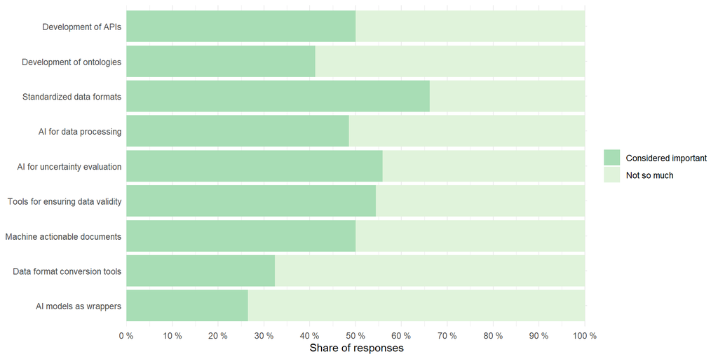

Figure 22: Share of respondents considering each tool important for the further development of digitalization in metrology

### 6.1 Development of APIs

There were comments supporting the importance of the development of APIs to support automated and interoperable exchange of data, even being possible to expand to machine-to-machine communication or machine actionable contents. Some comments point out the passive stance of institutes and their stakeholders, suggesting that further development of APIs and demonstrating its usefulness with a top-down approach may be valued. Some others support the APIs for UTC, temperature and CMCs in service or under development by the BIPM. Others anticipate API developments referring to and processing comparison data, giving established functions (such as thermocouples).

APIs can allow automated retrieval, submission, and validation of measurement data, Digital Calibration Certificates (DCCs), SI reference data, and KCDB information. Developing well-documented, standardized, and secure APIs supports interoperability, efficiency, and real-time integration of digital services, reducing manual work and ensuring data consistency across platforms.

### 6.2 Development of ontologies

Ontologies define concepts under metrology (for example, quantities, units, instruments, uncertainty) in a machine-readable way, enabling consistent interpretation, interoperability, and automated reasoning. They support integration of digital services, AI tools, and standardized data exchange across metrology systems. Comments supporting the BIPM to owe the fundamentals on developing the ontologies for metrology are seen, with some suggesting further expansions to further cover the VIM, GUM and the SI brochure.

Some comments ask for the BIPM to show how ontologies could be effectively used under their practical applications such as Digital Calibration Certificates.

### 6.3 Standardized data formats

Many institutes have interest in this field with the interest on the FAIR principles, machine readability, reuse of data and other aspects. Some further associate this to involving ISO and/or IEC with implying standards such as ISO/IEC 17025 (and possibly futher with ISO 17034 for reference matarial production).

Comments indicate the necessity of the development and standardization of metadata formats that can provide FAIR principles to the data and make the data machine readable/actionable. Formats that provide consistent structures for metrological information will enable machine-readability, interoperability, and reliable data exchange across laboratories, national metrology institutes, and international systems. Standard formats reduce errors, simplify integration with APIs and digital tools, and support automation and traceability in metrology workflows.

Some comments suggest that the BIPM should take the role of coordination on the important development. With pointing out the fact that one of the difficulties in implementing FAIR approaches and digitalization is that metadata production takes some amount of time, a comment acknowledging that having an activity of development of standardized data formats in digital frames is fundamental to make things easier and more effective, thus encouraging the adoption from different and heterogeneous communities is important. Some are asking for more details on the topic. Some also associate the development of ontologies in parallel and we need to be aware not to just blindly define the data format what that aspect in concern.

Creating harmonization will involve metadata, units, measurement conditions, traceability, and uncertainty, with possible additions such as version control, validation and verification to ensure the integrity of the data. However, an institute also remarked their awareness that due to the nature that data formats will continue to evolve and new ones will emerge, it may be more appropriate to place greater emphasis on ontology and semantics rather than focusing primarily on standardised formats.

### 6.4 AI for data processing

Most of those institutes that consider AI for data processing favors the AI’s capability to process vast amount of data in real-time, recongise patterns and trends underlying, and its applicability to further applications such as data cleaning, outlier detection and further automation including judgement. One institute raised a use case on “analysis of chemical signatures”, and “statistical and qualitative analysis of CRM (client calibration and testing) databases”.

Some institutes raised an alert on the risk related to trustworthiness and/or determinism of the AI, which may develop into a key interest topic in the future when many institutes get actively involved in applying AI for metrology.

### 6.5 AI for uncertainty evaluation

Regarding “AI for uncertainty evaluation”, the topic “uncertainty evaluation” itself seems to be a topic of high interest since some of the comments the institutes have even provided information on their existing projects that are less related to AI. However, we may be able to understand that there exists a motivation to further develop tools for “uncertainty evaluation” despite the existing tools, and the institutes are looking forward to the development of such tools with an insight of receiving benefit from the recent development of the AI. Many comments expect the ability of AI to find hidden patterns underlying in the data. Application to problems that might have been difficult for existing tools such as dealing with multivariable data that may have complexity due to the correlations between the measurands.

Some institutes also alert the necessity of careful validation and verification of the use of AI and the models derived from its use, upon consideration on the transparency of the results obtained, with setting such aspects to be a priority upon use of AI.

### 6.6 Tools for ensuring data validity

Responding to this question topic on the development of digital tools or infrastructure for ensuring the validity of information, such as cryptography, digital signatures, or other tools to ensure data security or integrity, the following items were raised from the institutes as important topic items.

- Establishment of an international anchor of trust in digital metrology and further suggesting the BIPM to contribute to take that role.
- Digital systems that guarantee the authenticity, integrity, and traceability of metrological data.
- Reliable tools for validation and data integrity.
- Issues on digital signatures, establishing credentials, possibility of training on such issues to ensure credibility.
- Data security including “zero trust” infrastructure.

### 6.7 Machine actionable documents

Regarding the development of machine-readable and machine-actionable documents, comments in two directions were raised.

Some comments are on making existing documents such as the VIM and the GUM to be translated into machine-readable and machine-actionable documents, probably having in mind other activities on SMART standards at ISO or the project on digitalization of OIML Recommendations.

The other comments appear to be more a request for documentation on the data format of the output of the institute such as digital calibration certificates, with some further suggestion reaching out to standardization activities. Creation of templates to reduce interpretation errors and unify the approaches seem to be common for those claiming the importance of this aspect. Besides the FAIR principles, an institute further raised their concern to anticipate for an agreed and internationally accepted formats will be critical to facilitate widespread adoption. Clear guidance on cyber security, interoperability, access restriction, privacy and data ownership provisions will be important to allow organisations to properly manage and balance risks and benefits within their national contexts.

There was one institute providing a detailed suggestion on the role of BIPM for this topic. The institute foresees that there are two possible roles for the BIPM in the development of readable and machine-actionable standards/guidance documents. On the one hand, collaborating with international standardisation organisations such as ISO and IEC in the future development of this type of standards and, on the other hand, transforming some of the guidance documents already developed by the CCs, such as the mise-en-pratique of the SI units into readable and machine-actionable formats.

### 6.8 Data format conversion tools

For the topic “Data format conversion tools”, those institutes that claim the topic as important commonly have the reuse or interoperability of existing data in mind. Despite of the value of having a shared practice, some comments also point out the practical difficulties that have already been experienced through their development of a laboratory information management system (LIMS) with having data produced from instruments by different vendors coexisting.

Some institutes suggest that the BIPM may act as the provider of such conversion tools through the SI Reference Point, however, this view might be more focusing on data conversion between different units of the same quantity such caused by the historical change in definitions of the unit, conventional values or scales under the SI.

### 6.9 AI models as wrappers

Not much institutes view the topic “development of AI models pretrained and updated specifically for metrology purposes functionable as wrappers for APIs” as important as other topics. This might be due to the fact that the propagation of the ability of Large Language Models (LLMs) is relatively recent, and furthermore that due to the risk of prompting input to the LLMs may be used by the AI provider for learning with lack of establishing an explicit “opt-out” agreement, some institutes may be observing the topic until their institute can manage a safe method to avoid risks and take the benefit of utilizing LLMs to their work.

However, from those institutes that claimed that they recognise the importance of this topic, AIs trained specifically for the purpose targeting metrology seems to be of some interest. Some highlight that such a tool implementation may be more of an interest for the consumers, and it is worth demonstrating its application for the consumer’s benefit. For such a case, NMIs and DIs or the BIPM may need to play a critically important role to review and ensure the output of the trained AI models are correct. Specific topics such as the difficulties for the consumer to directly access the KCDB and drawing out what they need may be a good application of such pretrained wrappers. Again, validation and verification of what the AI gives as a response will be a topic to ensure that the information that the metrology community provides will be correctly processed and provided though those AI tools.

### 6.10 Stakeholders

Respondents were asked which stakeholders the metrology community should engage with to further expand digitalization. The responses ranged from organizations within the metrology community itself to AI developers, standardization bodies, and sector-specific industries. The following paragraphs summarize the main categories of stakeholders identified.

Within the metrology community, NMIs, DIs, and RMOs are seen as the primary bodies for mutual collaboration, with particular emphasis on supporting developing economies through capacity building and knowledge transfer.

Along with the existing important stakeholders having a long history being in direct contact such as industry and accreditation bodies, an interesting proposal is to reach out to the developers of the AI, with emphasizing that the FAIR principles, tranperancy and trustworthyness of the AI that we would expect as working in metrology. Experts in blockchain and other technologies related to data integrity are also under some’s concern. Universities can also support fundamental and applied metrology research, digital methods development, capacity building and also bridge the gap between advanced and developing NMIs through joint projects and innovation partnerships.

In relation to data formats also providing the FAIR principles, standadization bodies such as International Organization for Standardization and International Electrotechnical Commission (one comment specificly naming ISO/IEC JTC 1, W3C, and OASIS) seem to be another stakeholder sector that we might be interested wishing to further involve. Software developers of LIMS, calibration management systems, IIoT/industrial data may have abundant information.

Other specific possibilities raised include, NCSLI, International Society for Automation (ISA), the World Energy Council (WEC), International Council of Chemical Associations (ICCA), the World Manufacturing Foundation (WMF, the International Federation of Robotics (IFR) or the Platform Industrie 4.0, OIML, WMO, CIE, UN bodies and IMEKO TC-6. Further fields and sectors such as medical related, food testing related, large energy companies, big pharmaceutical companies, major agriculture companies, logistics, public transportation, and aviation that may have existing digital formats specific to their fields are also suggested as stakeholders to involve.

Some comments include the request for the BIPM to be the interface with the bodies under the Quality Infrastructure. A comment expressing that the links between the organisations in the JSI are currently not being exploited as much as they could be, with the necessity of joint technical work done and then disseminated to the members of those organisations to highlight why this is useful and important, and further foreseeing that we can look beyond metrology at the wider group of end users of metrology.

Expectations that the BIPM should be the primary source of information for metrology could also be seen in the comments.

### 6.11 Further comments

Other than the ten topics above, the following were raised as further comments towards further development of digitalization in metrology.

- Expectations in BIPM’s leadership in digital metrology
- Continued emphasis on coherence
- Inclusive implementation and encouragement, with consideration on different levels of digital maturity.
- Development of practical guidance, training, and real-world examples for BIPM digital services
- Coordination to achieve internationally accepted standards
- Digitalization to support practical operations necessary under the CIPM MRA, such as conducting comparisons, paperwork for shipping artifacts
- Cryptography etc. to support data integrity
- Incorporate principles of versioning, long-term availability, reproducibility, and legally binding integrity
- It is essential to keep in mind that digitalisation should primarily simplify and improve the efficiency of metrological processes. Digitalisation efforts should not complicate the work of metrologists or burden them with IT-related tasks.

Comments such as the last item discussing the cost for digitalization that also may be linked to financial costs to develop and to maintain the activities for digitalization were not frequently found. However, this may be another important factor to keep in mind as our baseline when we review and evaluate the outcomes of the digitalization activities. Digitalization itself is not the objective, and the benefit should be to ease and enhance the activities for all of us including our stakeholders.

Nevertheless, we have started the collaboration under the JSI and further created the FORUM-MD to seek direction. The results reported in this survey provides information on our current position as well as the material to base our discussions on the further propagation of digitalization of metrology.

## 7 Acknowledgements

The authors wish to express their sincere gratitude to all the institutes that took the time to respond to this survey. Their contributions are essential to understanding the current state of digitalization in the metrology community and to guiding the future development of BIPM digital services. The authors also thank Johanne Flament from the BIPM Meetings Office for her assistance in setting up the survey form, and Anna Cypionka, Frédéric Meynadier, and Stéphanie Maniguet for their valuable input in reviewing the survey questions.

## 8 References

Iwan, Tomer. 2026. *Polyglotr: Translate Text*. https://doi.org/10.32614/CRAN.package.polyglotr.

Joint Committee for Guides in Metrology. 2012. “International Vocabulary of Metrology — Basic and General Concepts and Associated Terms (VIM).” JCGM 200:2012. 3rd ed. Bureau International des Poids et Mesures. https://doi.org/10.59161/JCGM200-2012.

Lewis, Andrew J, Andrew Yacoot, Martin J T Milton, and Andrew J Lancaster. 2022. “A Digital Framework for Realising the SI—a Proposal for the Metre.” *Metrologia* 59 (4): 044004. https://doi.org/10.1088/1681-7575/ac7fce.

Wickham, Hadley, Mara Averick, Jennifer Bryan, Winston Chang, Lucy D’Agostino McGowan, Romain François, Garrett Grolemund, et al. 2019. “Welcome to the tidyverse.” *Journal of Open Source Software* 4 (43): 1686. https://doi.org/10.21105/joss.01686.

Wilkinson, Mark D., Michel Dumontier, IJsbrand Jan Aalbersberg, Gabrielle Appleton, Myles Axton, Arie Baak, Niklas Blomberg, et al. 2016. “The FAIR Guiding Principles for Scientific Data Management and Stewardship.” *Scientific Data* 3 (1): 160018. https://doi.org/10.1038/sdata.2016.18.